# Git

2023-04-23

# 1 Main knowledge

## 1.1 First commit

1. add new branch: https://github.com/Ferran-pv/sp-scripts -> clicar a “main” (nom default branch)
2. Create token autentification: github -> settings -> developer settings -> personal acces tokens.
3. crees repo online -> en local el 1er que has de fer és ‘git init’ -> add + commit + push.

```r
ID: Ferran-PV
TOKEN: XX
```

```r
git config --global user.email "ferranpauls10@gmail.com"
git config --global user.name "Ferran-pv"
#
git init
git remote add origin https://github.com/Ferran-pv/sp-scripts.git
cd /home/pferran/scripts
git add .
git commit -m "Initial commit"
git push -u origin main # Careful: name of branch will be 'main'.
```

## 1.2 normal push

```r
cd /home/pferran/scripts
git add .
git commit -m backup
git push -u origin main
```

## 1.3 .gitignore

```r
# not any X folder
**/.venv
**/.ipynb_checkpoints
**/.virtual_documents
**/__pycache__
*personal.txt
```

# 2 Useful stuff

## 2.1 Clone repository

```r
git clone http[...].git
```

## 2.2 Reversing changes

reset = local, revert = remote.

```r
git reset --hard HEAD~1 # 1 commit before head
git revert HEAD
```

## 2.3 Fetch/pull

```r
git fetch
git merge origin main

# or, same thing
git pull
```

## 2.4 Render html file in Github

```r
https://raw.githack.com/
```

## 2.5 Branching

## 2.6 Which branch are you on?

```r
git status
```

### 2.6.1 New branch & change to it

```r
git branch <name>
git switch <name> # or checkout
```

### 2.6.2 Branch union

2 options: merge & rebase.

```r
git switch X # change to branch created to maintain the other stable
git commit # save changes
git switch main
git commit
# We are in 'main' branch.

########## merge
git merge bugFix # update main branch with changes.

########## rebase
git switch X
gitrebase main
```

# 3 Definitions

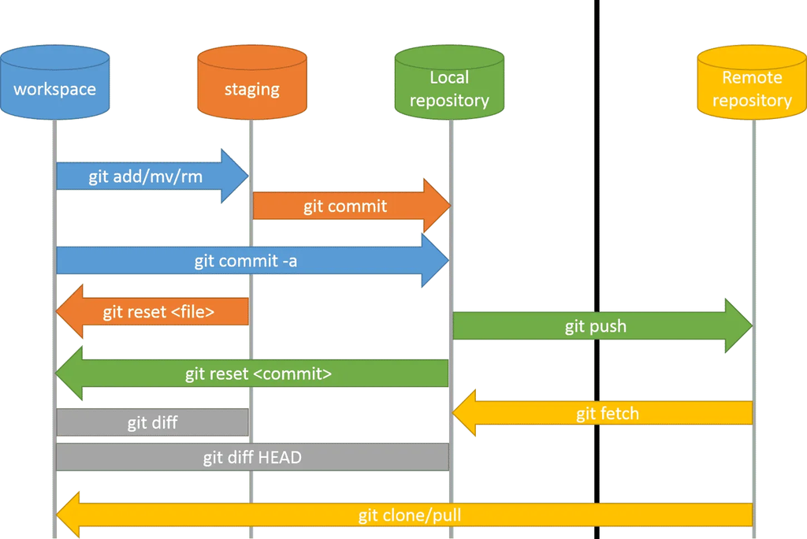

Git squeme

## 3.1 Main knowledge

**add:** takes a modified file in your working directory and places the modified version in a staging area (tracked files).

**commit:** records a snapshot of all the (tracked) files in your directory. It compresses a commit as a set of changes from one version of the local repository to the next.

**head:** A head is simply a reference to a commit object. At any given time, one head is selected as the ‘current head’ (i.e. latest commit in the branch you are in). This head is aliased to **HEAD**.

**fetch:** download non-updated changes from a remote repository.

- Doesn’t change your local

**pull:** fetches remote changes and then merges them.

**push:** uploading your changes to a specified remote (“publish” your work).

## 3.2 Branching

**merge:** To include the changes from one branch to the other branch.

- History is mantained.
- If you do it multiple times, the final squeme is messy.

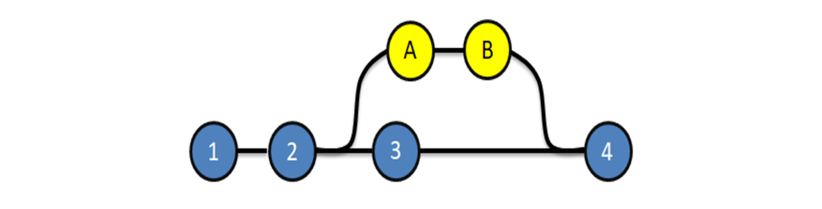

git merge

- Goal:make logs of repository history look linear.
- Problem: we cannot track when & how the commits were merged.

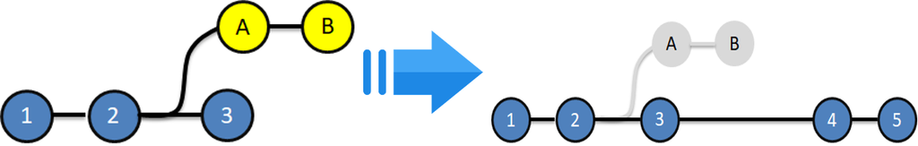

git rebase

## 3.3 Reversing changes

**reset:** will move a branch backwards as if the commit had never been made. Only in your local repository, not commited changes.

**revert:** reverse changes and share those reversed changes with others (i.e. applies to commited changes).